# Practical Machine Learning Course Project

Lanie E

Saturday, June 20, 2015

### Background

Using devices such as Jawbone Up, Nike FuelBand, and Fitbit it is now possible to collect a large amount of data about personal activity relatively inexpensively. These type of devices are part of the quantified self movement-a group of enthusiasts who take measurements about themselves regularly to improve their health, to find patterns in their behavior, or because they are tech geeks. One thing that people regularly do is quantify how much of a particular activity they do, but they rarely quantify how well they do it. In this project, your goal will be to use data from accelerometers on the belt, forearm, arm, and dumbell of 6 participants. They were asked to perform barbell lifts correctly and incorrectly in 5 different ways. More information is available from the website here: http://groupware.les.inf.puc-rio.br/har (see the section on the Weight Lifting Exercise Dataset).

### Data

The training data for this project are available here:

https://d396qusza40orc.cloudfront.net/predmachlearn/pml-training.csv

The test data are available here:

https://d396qusza40orc.cloudfront.net/predmachlearn/pml-testing.csv

The data for this project come from this source: http://groupware.les.inf.puc-rio.br/har. If you use the document you create for this class for any purpose please cite them as they have been very generous in allowing their data to be used for this kind of assignment.

What you should submit

The goal of your project is to predict the manner in which they did the exercise. This is the “classe” variable in the training set. You may use any of the other variables to predict with. You should create a report describing how you built your model, how you used cross validation, what you think the expected out of sample error is, and why you made the choices you did. You will also use your prediction model to predict 20 different test cases.

1. Your submission should consist of a link to a Github repo with your R markdown and compiled HTML file describing your analysis. Please constrain the text of the writeup to < 2000 words and the number of figures to be less than 5. It will make it easier for the graders if you submit a repo with a gh-pages branch so the HTML page can be viewed online (and you always want to make it easy on graders :-).
2. You should also apply your machine learning algorithm to the 20 test cases available in the test data above. Please submit your predictions in appropriate format to the programming assignment for automated grading. See the programming assignment for additional details.

### Initiating Library Package

```r
library(caret)
library(doParallel)
library(data.table)
library(randomForest)
set.seed(20150125)
```

### Loading Training Data and setting data location

The pml-training.csv data is used to devise training and testing sets during fitting of the model. The pml-test.csv data is used to submit 20 test cases based on the fitted model.

download.file(“https://d396qusza40orc.cloudfront.net/predmachlearn/pml-training.csv”, “pml-training.csv”,method=“auto”) download.file(“https://d396qusza40orc.cloudfront.net/predmachlearn/pml-testing.csv”,“pml-test.csv”,method=“auto” )

```r
setwd("C:/predictionAssignment_files/answers")
```

### Tidying data

Convert all blank(“”), “#DIV/0”" and “NA” values are converted to “NA”.

```r
trainingSrc   <- read.csv('C:/predictionAssignment_files/answers/pml-training.csv', na.strings=c("NA","#DIV/0!", ""))
testSrc       <- read.csv('C:/predictionAssignment_files/answers/pml-test.csv' , na.strings=c("NA", "#DIV/0!", ""))
```

```r
goodVars    <- which((colSums(!is.na(trainingSrc)) >= 0.6*nrow(trainingSrc)))
trainingSrc <- trainingSrc[,goodVars]
testSrc     <- testSrc[,goodVars]
```

Some minor fixes to test set are needed to perform well with random forests.

```r
# remove problem id
testSrc <- testSrc[-ncol(testSrc)]
# fix factor levels
testSrc$new_window <- factor(testSrc$new_window, levels=c("no","yes"))
```

Remove X and cvtd_timestamp colums from the dataset since they are not relevant

```r
trainingSrc <- trainingSrc[,-c(1,5)]
testSrc     <- testSrc[,-c(1,5)]
```

## Partition data into training and test sets

We are dividing data to 60% training and 40% testing sets.

```r
inTraining  <- createDataPartition(trainingSrc$classe, p = 0.6, list = FALSE)
training    <- trainingSrc[inTraining, ]
testing     <- trainingSrc[-inTraining, ]
```

## Fitting Random Forests

The outcome variable is class and other columns are in dataframe.

```r
class <- training$classe
data  <- training[-ncol(training)]
```

We will use Parallel Random Forest algorithm to fit the model. Note that for random forests there is no need for cross validation to get an unbiased estimate of the test set error. It is estimated internally during the fitting process.

```r
registerDoParallel()
rf <- train(data, class, method="parRF",
            tuneGrid=data.frame(mtry=3),
            trControl=trainControl(method="none"))

rf
```

```
## Parallel Random Forest
##
## 11776 samples
##    57 predictor
##     5 classes: 'A', 'B', 'C', 'D', 'E'
##
## No pre-processing
## Resampling: None
```

Let’s plot the importance of the model variables:

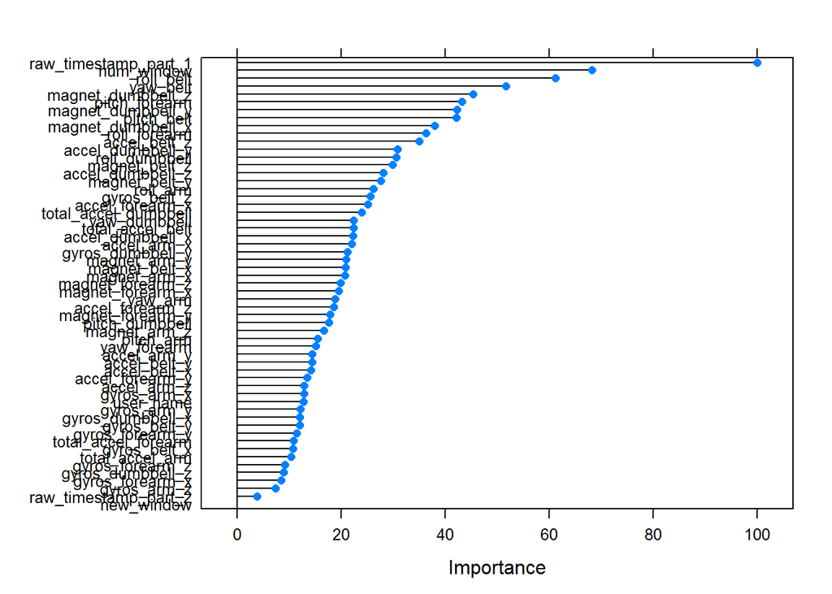

```r
plot(varImp(rf))
```

## Confusion Matrix for testing set

Predict on testing set and generate the confusion matrix for the testing set

```r
testingPredictions <- predict(rf, newdata=testing)
confMatrix <- confusionMatrix(testingPredictions,testing$classe)
confMatrix
```

```
## Confusion Matrix and Statistics
##
##           Reference
## Prediction    A    B    C    D    E
##          A 2231    1    0    0    0
##          B    1 1517    8    0    0
##          C    0    0 1358   15    0
##          D    0    0    2 1271    3
##          E    0    0    0    0 1439
##
## Overall Statistics
##
##                Accuracy : 0.9962
##                  95% CI : (0.9945, 0.9974)
##     No Information Rate : 0.2845
##     P-Value [Acc > NIR] : < 2.2e-16
##
##                   Kappa : 0.9952
##  Mcnemar's Test P-Value : NA
##
## Statistics by Class:
##
##                      Class: A Class: B Class: C Class: D Class: E
## Sensitivity            0.9996   0.9993   0.9927   0.9883   0.9979
## Specificity            0.9998   0.9986   0.9977   0.9992   1.0000
## Pos Pred Value         0.9996   0.9941   0.9891   0.9961   1.0000
## Neg Pred Value         0.9998   0.9998   0.9985   0.9977   0.9995
## Prevalence             0.2845   0.1935   0.1744   0.1639   0.1838
## Detection Rate         0.2843   0.1933   0.1731   0.1620   0.1834
## Detection Prevalence   0.2845   0.1945   0.1750   0.1626   0.1834
## Balanced Accuracy      0.9997   0.9990   0.9952   0.9938   0.9990
```

Let’s have a look at the accuracy.

```r
confMatrix$overall[1]
```

```
##  Accuracy
## 0.9961764
```

It looks very good - it is more than 99.6%.

# Submit results of Test Set

```r
pml_write_files = function(x){
  n = length(x)
  for(i in 1:n){
    filename = paste0("problem_id_",i,".txt")
    write.table(x[i],file=filename,quote=FALSE,row.names=FALSE,col.names=FALSE)
  }
}

answers <- predict(rf, testSrc)
pml_write_files(answers)
```